# 第九章 Z变换

马越

北京理工大学机械与车辆学院  
Email: yuema@bit.edu.cn  
̊

## 目录

- **1. 引言**
- 2. z变换及其收敛域
- 3. z逆变换
- 4. 利用零极点图对傅里叶变换进行几何求值
- 5. z变换性质
- 6. 常用z变换对
- 7. 用z变换分析与表征线性时不变系统

# 引言

## Z 变换

离散时间 LTI 系统对输入 $x[n]=z^n$ 的响应为
$$y[n]=(x*h)[n]=H(z)z^n$$
其中 $h$ 是系统的冲激响应，
$$H(z)=\sum_{k=-\infty}^{\infty} h[k]z^{-k}$$
系统函数 $H(z)$ 称为 $h$ 的 **Z 变换**。

一般地，离散时间信号 $x[n]$ 的 Z 变换定义为
$$X(z)=\sum_{n=-\infty}^{\infty} x[n]z^{-n}$$
也记作 $X=\mathcal{Z}\{x\}$ 或 $x[n]\stackrel{\mathcal{Z}}{\longleftrightarrow} X(z)$。

## Z 变换（续）

$$X(z)=\sum_{n=-\infty}^{\infty} x[n]z^{-n}=\sum_{n=-\infty}^{\infty} c_n z^n$$
是以 $z=0$ 为中心的 Laurent 级数，其 $z^n$ 项的系数为 $c_n=x[-n]$。

作为 Laurent 级数，Z 变换在以 0 为中心的某个环形区域（称为收敛域 ROC）上收敛。

## 与 DTFT 的关系

令 $z=re^{j\omega}$，则
$$X(re^{j\omega})=\sum_{n=-\infty}^{\infty} \{x[n]r^{-n}\}e^{-j\omega n}=\mathcal{F}\{x[n]r^{-n}\}$$
若 ROC 包含单位圆，令 $r=1$ 可得
$$X(e^{j\omega})=\mathcal{F}\{x\}$$

## 例题

对于 $x[n]=a^n u[n]$，
$$X(z)=\sum_{n=0}^{\infty}a^n z^{-n}=\frac{1}{1-a z^{-1}}=\frac{z}{z-a}, \quad \mathrm{ROC}: |z|>|a|$$

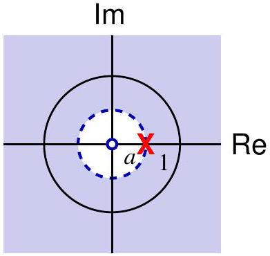

若 $|a|<1$，ROC 包含单位圆，DTFT 存在；若 $|a|>1$，DTFT 不存在。

## 例题（反因果序列）

对于 $x[n]=-a^n u[-n-1]$，
$$X(z)=\frac{z}{z-a}, \quad \mathrm{ROC}: |z|<|a|$$

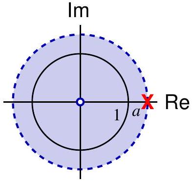

## 收敛域（ROC）的重要性

相同 $X(z)$ 但不同的 ROC 对应不同的信号。**必须始终注明 ROC**！

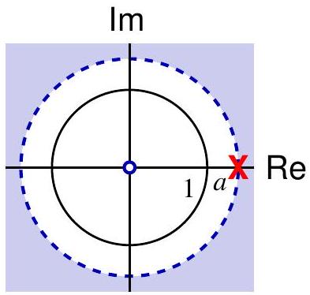

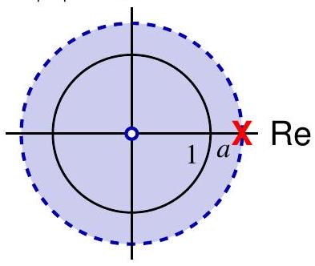

## 例题

$x[n]=7\left(\frac13\right)^n u[n]-6\left(\frac12\right)^n u[n]$，
$$X(z)=\frac{z\left(z-\frac32\right)}{\left(z-\frac13\right)\left(z-\frac12\right)}, \quad |z|>\frac12$$

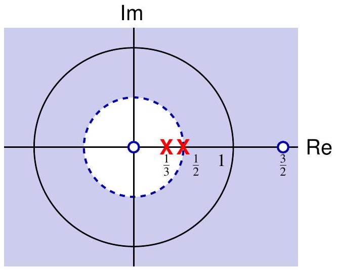

## 例题（正弦调制）

$x[n]=\left(\frac13\right)^n \sin\left(\frac{\pi}{4}n\right)u[n]$，
$$X(z)=\frac{\frac{1}{3\sqrt{2}}z}{\left(z-\frac13 e^{j\pi/4}\right)\left(z-\frac13 e^{-j\pi/4}\right)}, \quad |z|>\frac13$$

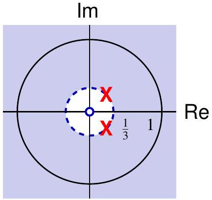

## 有理 Z 变换

有理 Z 变换形式为
$$X(z)=\frac{N(z)}{D(z)}$$
其中 $N,D$ 是互质多项式。

$$X(z)=A\frac{\prod_{k=1}^n (z-z_k)}{\prod_{k=1}^m (z-p_k)}$$
$z_k$ 为有限零点，$p_k$ 为有限极点。

有理 Z 变换由其极零点图和 ROC（差一个常数因子）唯一确定。

## ROC 的性质

- ROC 是环形区域 $R_1<|z|<R_2$；
- $X(z)$ 在 ROC 内解析；
- 有限时长信号：$R_1=0$，$R_2=\infty$；
- 因果信号（$N_1\geq0$）：ROC 为 $|z|>R_1$（包含 $\infty$）；
- 反因果信号（$N_2\leq0$）：ROC 为 $|z|<R_2$（包含 0）。

**左边信号**：$R_1=0$；**右边信号**：$R_2=\infty$；**双边信号**：$R_1>0$ 且 $R_2<\infty$。

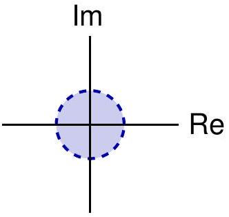

left-sided

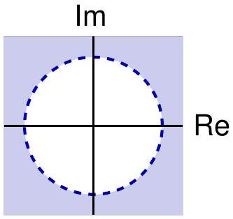

right-sided

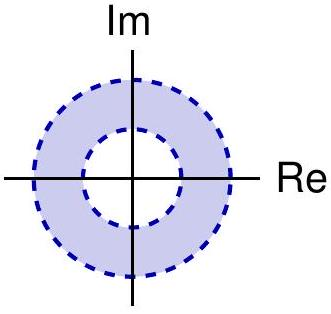

two-sided

## 有理 Z 变换的 ROC

对于有理 $X(z)$，ROC 被极点界定（向内至 0 或向外至 $\infty$）。

- 右边信号：$R_1=\max |p_k|$，$R_2=\infty$；
- 左边信号：$R_1=0$，$R_2=\min |p_k|$。

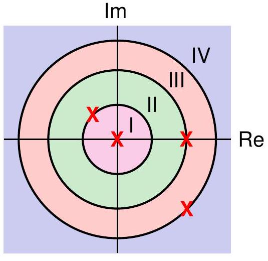

## 逆 Z 变换

$$x[n]=\frac{1}{j2\pi}\oint_C X(z)z^{n-1}\,dz$$
（$C$ 为 ROC 内围绕 0 的正向圆周），或通过部分分式展开、已知级数展开等方法求 Laurent 级数。

**注意**：$x[n]$ 是 $z^{-n}$ 的系数，而非 $z^n$ 的系数。

## Z 变换的性质

**线性性质**：
$$ax[n]+by[n] \stackrel{z}{\longleftrightarrow} aX(z)+bY(z)，\quad \mathrm{ROC} \supset \mathrm{ROC}_1 \cap \mathrm{ROC}_2$$

**时移性质**：
$$x[n-n_0] \stackrel{z}{\longleftrightarrow} z^{-n_0} X(z)$$

**z 域尺度变换**：
$$z_0^n x[n] \stackrel{z}{\longleftrightarrow} X\left(\frac{z}{z_0}\right)$$

**时间反转**：
$$x[-n] \stackrel{z}{\longleftrightarrow} X(z^{-1})$$

**时间扩展**：
$$x_{(k)}[n] \stackrel{z}{\longleftrightarrow} X(z^k)$$

**共轭**：
$$x^*[n] \stackrel{z}{\longleftrightarrow} X^*(z^*)$$

**z 域微分**：
$$n x[n] \stackrel{z}{\longleftrightarrow} -z \frac{d}{dz} X(z)$$

## 初值定理

若 $x[n]$ 为因果序列（$x[n]=0$ for $n<0$），则
$$x[0]=\lim_{z\to\infty} X(z)$$

## 终值定理

若 $x[n]$ 为因果序列且 ROC 包含单位圆，则
$$\lim_{n\to\infty} x[n] = \lim_{z\to1}(z-1)X(z)$$

## 卷积性质

$$(x*y)[n] \stackrel{z}{\longleftrightarrow} X(z)Y(z)$$

## DT 系统函数

$$Y(z)=X(z)H(z)$$
$H(z)$ 称为系统函数（传递函数）。

## 因果性

LTI 系统为因果的充要条件是：

- ROC 为圆外区域（包含 $\infty$）；
- $\lim_{z\to\infty} H(z)$ 存在且有限。

对有理 $H(z)$：ROC 为 $|z| >$ 最外层极点，且 $\deg D \geq \deg N$。

## 稳定性

LTI 系统稳定 $\iff$ ROC 包含单位圆 $|z|=1$。

**因果有理系统**稳定 $\iff$ 所有极点位于单位圆内部。

## 离散时间系统函数

离散时间 LTI 系统对输入 $x[n]$ 的响应为
$$y[n]=(x*h)[n]$$
其中 $h$ 是系统的冲激响应。

若 $x$ 和 $h$ 存在 Z 变换，根据卷积性质可得
$$Y(z)=X(z)H(z)$$
在它们公共的 ROC 内成立。

若 ROC 具有非空内点，则系统函数（又称传递函数）$H(z)$ 通过 Laurent 级数展开
$$H(z)=\sum_{n=-\infty}^{\infty} h[n]z^{-n}$$
唯一确定 $h$，进而确定系统性质。

## 因果性

回忆：$h$ 是右边序列当且仅当其 ROC 为圆外区域，即 $R_1<|z|<\infty$
$$H(z)=\sum_{n=N_1}^{\infty} h[n]z^{-n}$$

以下条件等价：

1. $N_1 \geq 0$
2. $H(z^{-1})=\sum_{n=N_1}^{\infty} h[n]z^n$ 在 $|z|<\frac{1}{R_1}$ 上是收敛的幂级数
3. $H(z^{-1})$ 在 $z=0$ 处为可去奇点
4. $H(z)$ 在 $z=\infty$ 处为可去奇点
5. $\lim_{z\to 0} H(z^{-1})$ 存在且有限
6. $\lim_{z\to \infty} H(z)$ 存在且有限

## 因果性

具有系统函数 $H(z)$ 的 LTI 系统是因果的，当且仅当

1. ROC 是圆外区域
2. $\lim_{z\to \infty} H(z)$ 存在且有限

$$\text{因果} \Longleftrightarrow \text{ROC 是包含 }\infty\text{ 的圆外区域}$$

对于有理系统函数 $H(z)=\frac{N(z)}{D(z)}$，系统因果当且仅当

1. ROC 为 $|z|>|p|$，其中 $p$ 是最外层的极点
2. $\deg D \geq \deg N$

**例**：$H(z)=\frac{z^3-2z^2-z}{z^2+\frac14 z+\frac18}$ 不能作为因果系统的系统函数。

## 稳定性

LTI 系统稳定当且仅当其冲激响应 $h\in \ell_1$，即
$$\sum_{n=-\infty}^{\infty}|h[n]|<\infty$$
这等价于 $H(z)$ 在单位圆 $|z|=1$ 上绝对收敛，因此其 ROC 必须满足 $R_1<1<R_2$。

$$\text{稳定} \Longleftrightarrow \text{ROC 包含单位圆 }|z|=1$$

因果的有理 LTI 系统稳定当且仅当其所有极点都在单位圆内。

**例**：因果系统 $H(z)=\frac{1}{1-a z^{-1}}$ 在 $|a|<1$ 时稳定。  
**例**：$H(z)=\frac{1}{1-a z^{-1}}$ 当 $|a|>1$ 且 ROC 为 $|z|<|a|$ 时也稳定，但系统是非因果的。

## 例

$$H(z)=\frac12\left[\frac{z}{z-\frac32}-\frac{z}{z+\frac12}\right]$$
存在两个极点 $p_1=-\frac12$ 和 $p_2=\frac32$。

1. $|z|>\frac32$：因果，不稳定  
   $h_1[n]=\frac12\left(\frac32\right)^n u[n]-\frac12\left(-\frac12\right)^n u[n]$

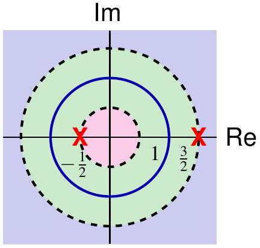

2. $\frac12<|z|<\frac32$：非因果，稳定  
   $h_2[n]=-\frac12\left(\frac32\right)^n u[-n-1]-\frac12\left(-\frac12\right)^n u[n]$
3. $|z|<\frac12$：非因果，不稳定  
   $h_3[n]=-\frac12\left(\frac32\right)^n u[-n-1]+\frac12\left(-\frac12\right)^n u[-n-1]$

## 线性常系数差分方程

LTI 系统的输入输出满足
$$\sum_{k=0}^N a_k y[n-k] = \sum_{k=0}^M b_k x[n-k]$$
对两边取 Z 变换
$$\sum_{k=0}^N a_k z^{-k} Y(z) = \sum_{k=0}^M b_k z^{-k} X(z)$$
故系统函数
$$H(z)=\frac{Y(z)}{X(z)}=\frac{\sum_{k=0}^M b_k z^{-k}}{\sum_{k=0}^N a_k z^{-k}}$$
系统函数总是有理的。**差分方程本身不指定 ROC**，需要额外条件（如稳定性、因果性）来确定 $h[n]$。

## 例

考虑 LTI 系统：
$$y[n]-\frac12 y[n-1]=x[n]+\frac13 x[n-1]$$
系统函数
$$H(z)=\frac{1+\frac13 z^{-1}}{1-\frac12 z^{-1}}$$
ROC 有两种可能：$|z|>\frac12$ 和 $|z|<\frac12$。

1. 若 $|z|>\frac12$
   $$\frac{1}{1-\frac12 z^{-1}}=\sum_{n=0}^\infty \left(\frac12\right)^n z^{-n} \stackrel{z^{-1}}{\longleftrightarrow} \left(\frac12\right)^n u[n]$$
   由线性性和时移性质得
   $$h[n]=\left(\frac12\right)^n u[n] + \frac13\left(\frac12\right)^{n-1} u[n-1]$$

## 例（续）

2. 若 $|z|<\frac12$
   $$\frac{1}{1-\frac12 z^{-1}}=\frac{-2z}{1-2z}=-\sum_{n=1}^\infty 2^n z^n \stackrel{z^{-1}}{\longleftrightarrow} -\left(\frac12\right)^n u[-n-1]$$
   故
   $$h[n]=-\left(\frac12\right)^n u[-n-1] - \frac13\left(\frac12\right)^{n-1} u[-n]$$

## 例（续）

若使用傅里叶变换，则频率响应为
$$H(e^{j\omega})=\frac{1+\frac13 e^{-j\omega}}{1-\frac12 e^{-j\omega}}$$
对应的 $h[n]$ 为因果形式。

**原因**：傅里叶变换方法隐含假设系统稳定（ROC 包含单位圆，即 $|z|>\frac12$），一般不适用于不稳定系统。

## 例

考虑差分方程
$$y[n]-\frac34 y[n-1]+\frac18 y[n-2]=2x[n]$$
系统函数
$$H(z)=\frac{2}{1-\frac34 z^{-1}+\frac18 z^{-2}}$$
部分分式展开得
$$H(z)=\frac{4}{1-\frac12 z^{-1}} - \frac{2}{1-\frac14 z^{-1}}$$
对应的冲激响应（三种 ROC）：
$$\begin{cases}
h_1[n]=4\left(\frac12\right)^n u[n]-2\left(\frac14\right)^n u[n], & |z|>\frac12 \\
h_2[n]=-4\left(\frac12\right)^n u[-n-1]-2\left(\frac14\right)^n u[n], & \frac14<|z|<\frac12 \\
h_3[n]=-4\left(\frac12\right)^n u[-n-1]+2\left(\frac14\right)^n u[-n-1], & |z|<\frac14
\end{cases}$$

## 例（续）

输入 $x[n]=\left(\frac14\right)^n u[n]$，$X(z)=\frac{1}{1-\frac14 z^{-1}}$，$|z|>\frac14$。

输出 Z 变换
$$Y(z)=H(z)X(z)=\frac{2}{\left(1-\frac12 z^{-1}\right)\left(1-\frac14 z^{-1}\right)^2}$$
仅在 $|z|>\frac12$ 和 $\frac14<|z|<\frac12$ 时有定义（$h_3*x$ 无定义）。

部分分式展开后可求得前两种情况的响应。

## 逆 Z 变换补充

$$\frac{1}{(1-a z^{-1})^m} \stackrel{z}{\longleftrightarrow} \binom{n+m-1}{m-1} a^n u[n], \quad |z|>|a|$$
$$\frac{1}{(1-a z^{-1})^m} \stackrel{z}{\longleftrightarrow} (-1)^m \binom{-n-1}{m-1} a^n u[-n-m], \quad |z|<|a|$$

## 例

因果 LTI 系统
$$y[n]-\frac12 y[n-1]=x[n]+\frac23 x[n-1]$$
输入 $x[n]=\left(-\frac23\right)^n u[n]$。

$$H(z)=\frac{1+\frac23 z^{-1}}{1-\frac12 z^{-1}}, \quad |z|>\frac12$$
$$X(z)=\frac{1}{1+\frac23 z^{-1}}, \quad |z|>\frac23$$
$$Y(z)=\frac{1}{1-\frac12 z^{-1}}, \quad |z|>\frac12 \Longrightarrow y[n]=\left(\frac12\right)^n u[n]$$

由于 $z=-\frac23$ 处零极点抵消，$Y(z)$ 的 ROC 大于 $X(z)$ 和 $H(z)$ ROC 的交集。

## 例

已知： 1. 输入 $x_1[n]=\left(\frac16\right)^n u[n]$ 时，输出 $y_1[n]=\left[a\left(\frac12\right)^n + 10\left(\frac13\right)^n\right] u[n]$ 2. 输入 $x_2[n]=(-1)^n$ 时，输出 $y_2[n]=\frac74 (-1)^n$

求 $H(z)$。

由条件1得
$$H(z)=\frac{Y_1(z)}{X_1(z)}=\frac{[(a+10)-(5+\frac{a}{3})z^{-1}](1-\frac16 z^{-1})}{(1-\frac12 z^{-1})(1-\frac13 z^{-1})}$$
由条件2：$H(-1)=\frac74$，解得 $a=-9$，从而
$$H(z)=\frac{(1-2z^{-1})(1-\frac16 z^{-1})}{(1-\frac12 z^{-1})(1-\frac13 z^{-1})}$$

## 例（续）

$H(z)$ 有三种可能的 ROC： - $|z|<\frac13$ - $\frac13<|z|<\frac12$ - $|z|>\frac12$

由 $Y_1(z)$ 的 ROC 包含 $X_1$ 和 $H$ 的 ROC 交集，可知 ROC 为 $|z|>\frac12$（稳定）。又 $H(\infty)=1$ 有限，故系统因果。

对应的差分方程为
$$y[n]-\frac56 y[n-1]+\frac16 y[n-2]=x[n]-\frac{13}6 x[n-1]+\frac13 x[n-2]$$

## 目录

1. 利用 Z 变换分析 DT LTI 系统
2. 框图表示
3. 单边 Z 变换

## 系统互连

**串联（级联）系统**：
$$Y=(X H_1)H_2 = X(H_1 H_2) = (X H_2)H_1$$

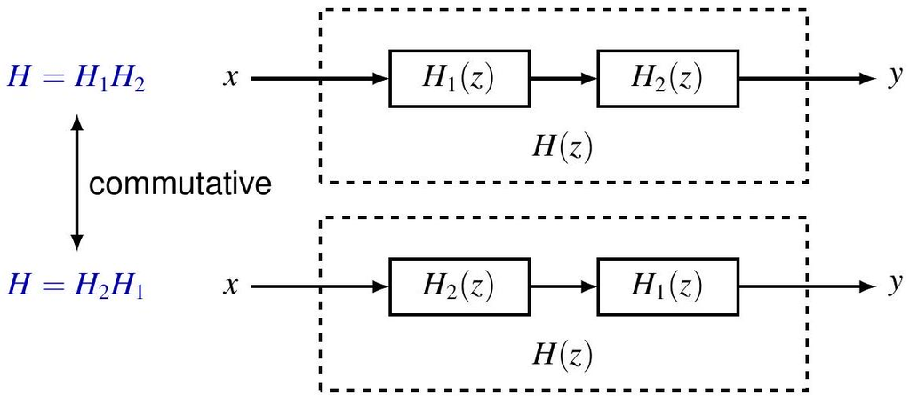

**并联系统**：
$$h=h_1+h_2, \quad H=H_1+H_2$$

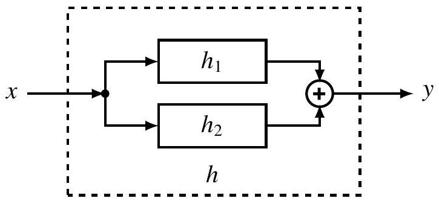

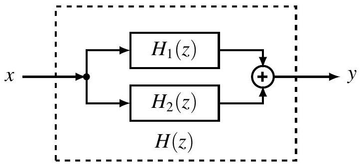

**反馈系统**：
$$H=\frac{H_1}{1+H_1 H_2}$$

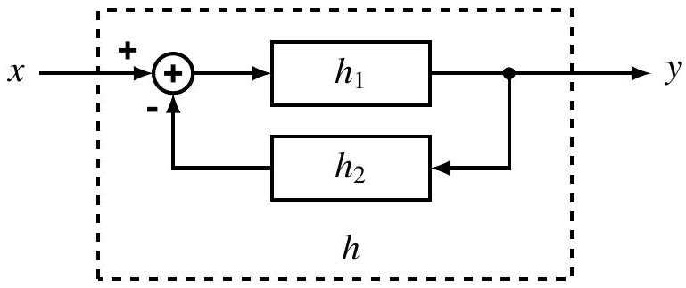

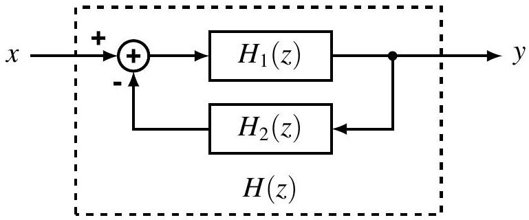

## 例（直接形式）

因果系统 $H(z)=\frac{1}{1-a z^{-1}}$，$|z|>|a|$ 对应差分方程
$$y[n]-a y[n-1]=x[n]$$
（初始静止条件）。

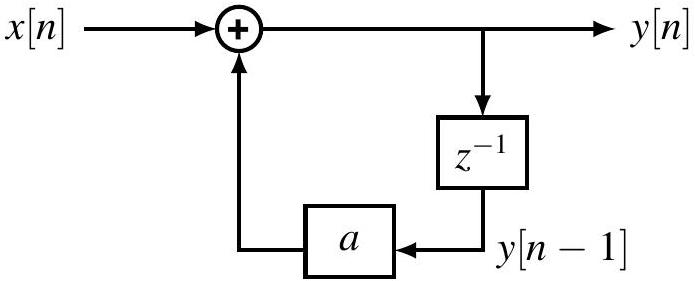

## 例（直接形式 II）

$$H(z)=\frac{1-b z^{-1}}{1-a z^{-1}}$$

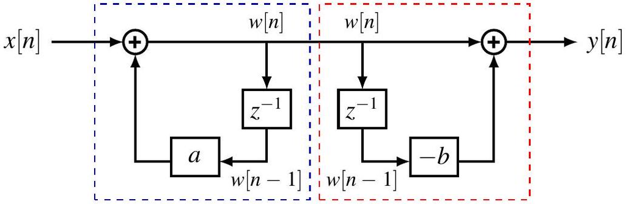

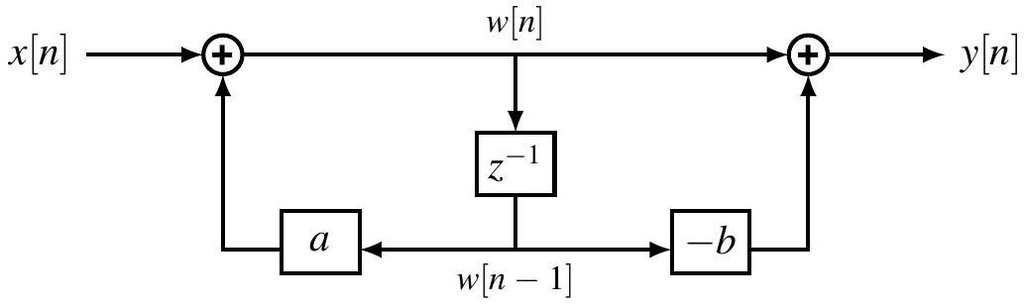

## 例（直接形式）

$$H(z)=\frac{1}{(1+\frac12 z^{-1})(1-\frac14 z^{-1})}=\frac{1}{1+\frac14 z^{-1}-\frac18 z^{-2}}$$
对应差分方程
$$y[n]+\frac14 y[n-1]-\frac18 y[n-2]=x[n]$$

**Direct Form**

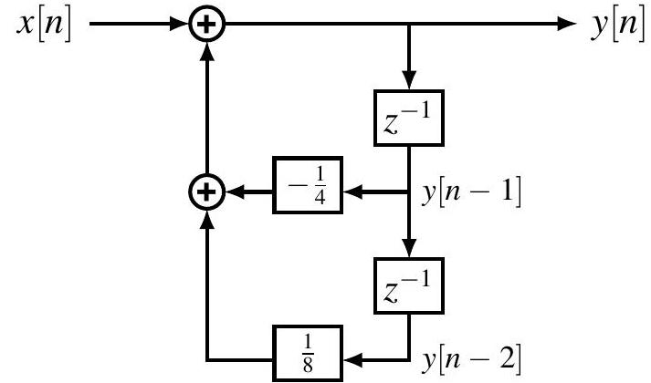

**Cascade Form**

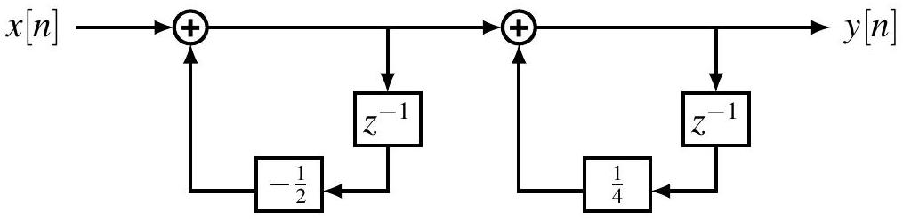

**Parallel Form**

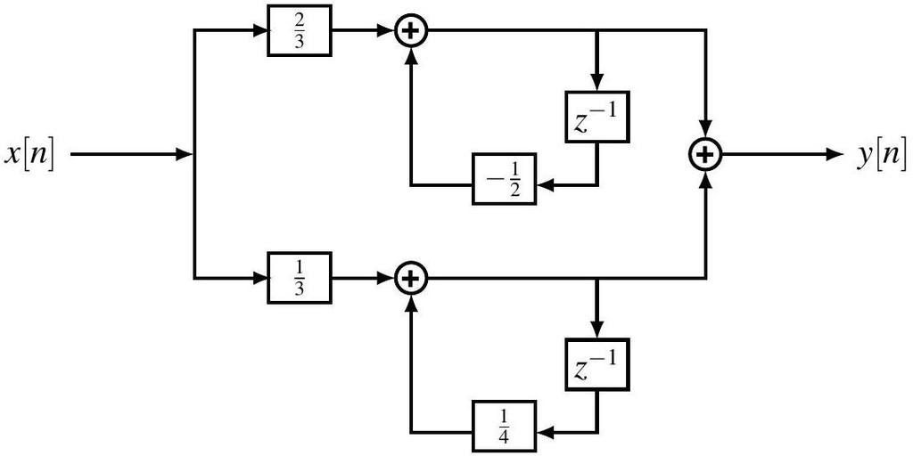

## 目录

1. 利用 Z 变换分析 DT LTI 系统
2. 框图表示
3. 单边 Z 变换

## 单边 Z 变换

双边 Z 变换：
$$X(z)=\sum_{n=-\infty}^{\infty} x[n]z^{-n}$$
单边 Z 变换（单侧 Z 变换）：
$$X(z)=\sum_{n=0}^{\infty} x[n]z^{-n}$$
也记作 $\mathcal{UZ}\{x\}$ 或 $x[n]\stackrel{uz}{\longleftrightarrow} X(z)$。

注意：$\mathcal{UZ}\{x\}=\mathcal{Z}\{x u[n]\}$。

- 单边 Z 变换的 ROC 总是圆外区域（包含 $\infty$）
- 有理情况下 $\deg N \leq \deg D$
- $\mathcal{Z}\{x\}=\mathcal{UZ}\{x\}$ 当且仅当 $x[n]=0$（$n<0$）

## 例

单边 Z 变换的计算与双边几乎相同，只需对 $n\geq 0$ 求和。

**例**：$x_1[n]=a^n u[n]$，
$$X_1(z)=\frac{1}{1-a z^{-1}}, \quad |z|>|a|$$

**例**：$x_2[n]=a^{n+1} u[n+1]=x_1[n+1]$， 理论上 $z X_1(z)$，但实际计算得 $\frac{a}{1-a z^{-1}}$。

## 单边逆 Z 变换

单边逆 Z 变换计算方法与双边相同，但只能恢复 $n\geq 0$ 的值。

## 单边 Z 变换的性质

多数性质与双边相同。

| 性质 | 信号 | 单边 Z 变换 |
| --- | --- | --- |
| - | $x[n]$ | $X(z)$ |
| 线性 | $a x[n]+b y[n]$ | $a X(z)+b Y(z)$ |
| z 域尺度变换 | $z_0^n x[n]$ | $X(z/z_0)$ |
| 时间扩展 | $x_{(k)}[n]$ | $X(z^k)$ |
| 共轭 | $x^*[n]$ | $X^*(z^*)$ |
| z 域微分 | $n x[n]$ | $-z \frac{d}{dz} X(z)$ |
| 初值定理 | $x[0]=\lim_{z\to\infty} X(z)$ | - |

## 单边 Z 变换的卷积性质

若 $x[n]=y[n]=0$（$n<0$），则
$$(x*y)[n] \stackrel{uz}{\longleftrightarrow} X(z)Y(z)$$

**注意**：该性质要求信号因果，否则不成立。

## 单边 Z 变换的时延性质

$$x[n-m] \stackrel{uz}{\longleftrightarrow} z^{-m}\left(X(z)+\sum_{k=1}^m x[-k]z^k\right)$$

## 单边 Z 变换的时超性质

$$x[n+m] \stackrel{uz}{\longleftrightarrow} z^m \left(X(z)-\sum_{k=0}^{m-1} x[k]z^{-k}\right)$$

## 用单边 Z 变换解线性常系数差分方程

差分方程
$$\sum_{k=0}^N a_k y[n-k]=\sum_{k=0}^M b_k x[n-k]$$
已知初始条件 $y[-1],\dots,y[-N]$ 及因果输入 $x[n]=0$（$n<0$）。

单边 Z 变换后可分离出**零状态响应**和**零输入响应**。

## 例

差分方程
$$y[n]+2 y[n-1]=x[n]$$
初始条件 $y[-1]=\beta$，输入 $x[n]=\alpha u[n]$。

## 例（续）

另一差分方程
$$y[n]-y[n-1]-2 y[n-2]=x[n]+2 x[n-2]$$
初始条件 $y[-1]=2$，$y[-2]=-\frac12$，$x[n]=u[n]$。